# Assignment 5 - Data Visualization (Incarceration)

Ryder Forsythe

2024-05-27

## Introduction

I chose to look at the percentage of incarcerated individuals who are not white, and compared that to the percentage of nonwhite individuals between ages 15 and 64 in the general population. The total percentage of incarcerated individuals who are not white in 2016, the most recent year with complete data, is 60.25%, far higher than the percentage of nonwhite people between the ages of 15 and 64 in the general population, which in 2016 was 39.67%. This percentage is highest in the state of California, at 78.48%. This percentage has decreased by 17.5% since 1990, when 77.6% of the incarcerated population was not white, a staggeringly higher percentage than in the general population, which was only 24.25% nonwhite. This indicates a dramatic, systemic bias in which people were incarcerated - one that has only somewhat abated since then.

## Data

These datasets were collated and published by the Vera Institute of Justice, using public datasets from the United States Department of Justice Bureau of Justice Statistics (BJS), as well as from various state departments of correction where federal data was not available or incomplete. These agencies collected data through a variety of surveys and sources, including the National Corrections Reporting Program, the Annual Survey of Jails, the Census of Jails, the Uniform Crime Reporting Program, National Vital Statistics System Data from the Department of Agriculture, and the Death in Custody Reporting Program. All together, this dataset presents as complete a look as possible at race and ethnicity in prisons and jails in the United States from 1970 to 2018, aggregated by county. In the Prison Population (prison_pop) dataset, which I focused on, there are 153811 rows and 37 columns. This dataset intersects two very important societal areas of interest - mass incarceration and systemic racial discrimination. It is therefore very important that this be as accurate to the real world as possible, because it demonstrates a clear set of systemic biases towards the incarceration of nonwhite people. Several states do not have counties with recorded prison populations; racial data within prisons is only available from 1990 on, and it is unclear whether any counties with prisons have been excluded due to a lack of data.

## Trends Over Time

```r
# load packages and data
library(tidyverse)
library(scales)
```

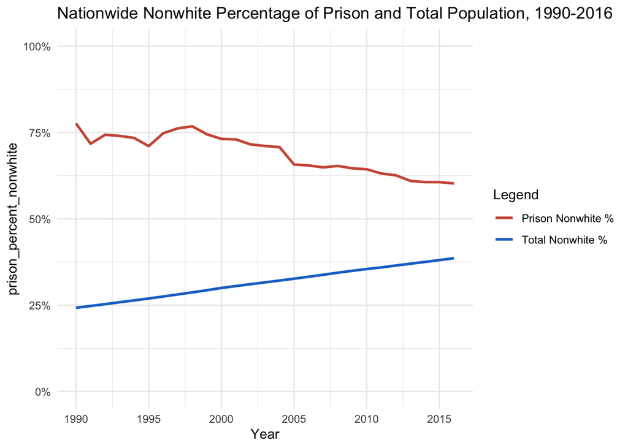

```r
prison_pop <- read.csv(url("https://raw.githubusercontent.com/melaniewalsh/Neat-Datasets/main/us-prison-pop.csv"))

# create new variables and set up new dataframe grouped by year
prison_pop_by_year <- prison_pop %>%
  group_by(year) %>%
  summarize(
    prison_percent_nonwhite = 1 - sum(white_prison_pop, na.rm = TRUE) / sum(total_prison_pop, na.rm = TRUE),
    total_percent_nonwhite = 1 - sum(white_pop_15to64, na.rm = TRUE)/sum(total_pop_15to64, na.rm = TRUE)
  )

# create line graph
legend_colors <- c("Prison Nonwhite %" = "coral3", "Total Nonwhite %" = "dodgerblue3")
chart1 <- filter(prison_pop_by_year, year > 1989 & year < 2017) %>% ggplot(aes(x = year)) +
  geom_line(aes(y = prison_percent_nonwhite, color = "Prison Nonwhite %"), linewidth = 1) +
  geom_line(aes(y = total_percent_nonwhite, color = "Total Nonwhite %"), linewidth = 1) +
  coord_cartesian(xlim = c(1990, 2016), ylim = c(0, 1)) +
  labs(
    x = "Year",
    title = "Nationwide Nonwhite Percentage of Prison and Total Population, 1990-2016",
    color = "Legend"
  ) +
  theme_minimal() +
  scale_x_continuous(breaks = seq(from = 1990, to = 2016, by = 5)) +
  scale_y_continuous(labels = percent) +
  scale_color_manual(values = legend_colors)

chart1
```

## Variable Comparison

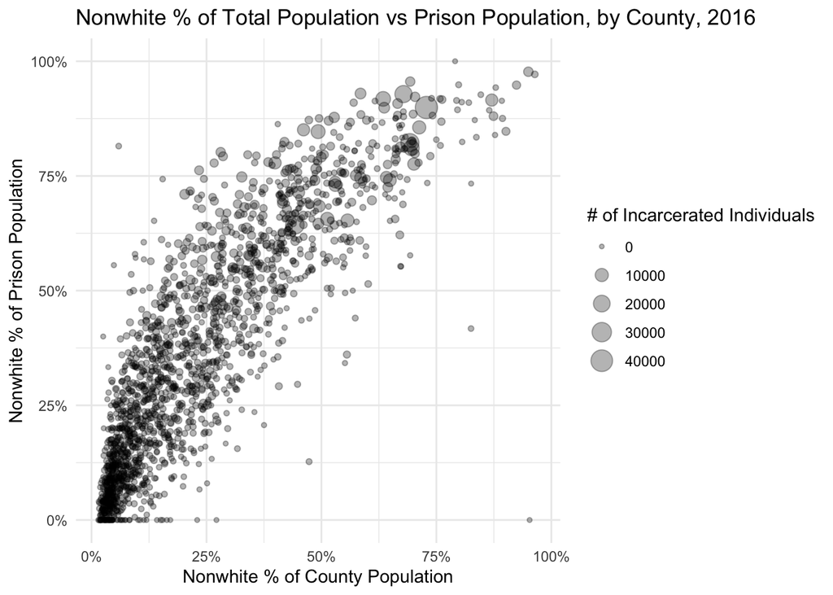

```r
# isolate 2016
prison_pop_2016 <- prison_pop %>% filter(year == "2016") %>%
  mutate(nonwhite_total_percentage = 1 - white_pop_15to64/total_pop_15to64,
         nonwhite_prison_percentage = 1 - white_prison_pop/total_prison_pop
         )
# create scatterplot
prison_pop_2016 %>% ggplot(aes(x = nonwhite_total_percentage, y = nonwhite_prison_percentage)) +
  geom_point(aes(size = total_prison_pop), alpha = 0.3) +
  labs(
    x = "Nonwhite % of County Population",
    y = "Nonwhite % of Prison Population",
    title = "Nonwhite % of Total Population vs Prison Population, by County, 2016",
    size = "# of Incarcerated Individuals"
  ) +
  theme_minimal() +
  scale_x_continuous(labels = percent) +
  scale_y_continuous(labels = percent)
```

## Map

```r
# load packages and data
library(tidyverse)
library(scales)
library(sf)
```

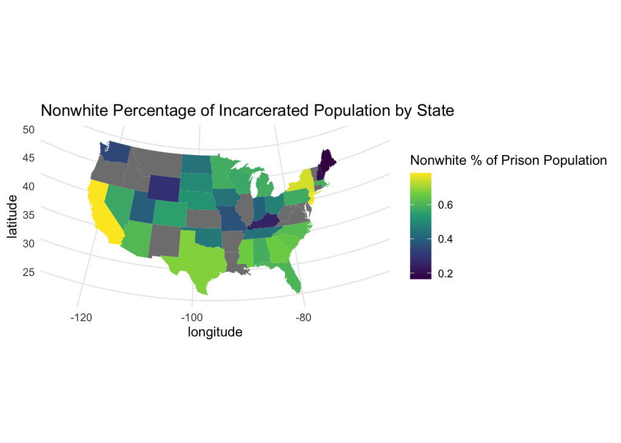

```r
library(maps)
prison_pop <- read.csv(url("https://raw.githubusercontent.com/melaniewalsh/Neat-Datasets/main/us-prison-pop.csv"))

states <- map_data("state")

# reformat states to match map_data package defaults
prison_pop$state <- prison_pop$state %>%
  case_match("AL" ~ "alabama",
             "AK" ~ "alaska",
             "AZ" ~ "arizona",
             "AR" ~ "arkansas",
             "CA" ~ "california",
             "CO" ~ "colorado",
             "CT" ~ "connecticut",
             "DE" ~ "delaware",
             "DC" ~ "district of columbia",
             "FL" ~ "florida",
             "GA" ~ "georgia",
             "HI" ~ "hawaii",
             "ID" ~ "idaho",
             "IL" ~ "illinois",
             "IN" ~ "indiana",
             "IA" ~ "iowa",
             "KS" ~ "kansas",
             "KY" ~ "kentucky",
             "LA" ~ "louisiana",
             "ME" ~ "maine",
             "MD" ~ "maryland",
             "MA" ~ "massachusetts",
             "MI" ~ "michigan",
             "MN" ~ "minnesota",
             "MS" ~ "mississippi",
             "MO" ~ "missouri",
             "MT" ~ "montana",
             "NE" ~ "nebraska",
             "NV" ~ "nevada",
             "NH" ~ "new hampshire",
             "NJ" ~ "new jersey",
             "NM" ~ "new mexico",
             "NY" ~ "new york",
             "NC" ~ "north carolina",
             "ND" ~ "north dakota",
             "OH" ~ "ohio",
             "OK" ~ "oklahoma",
             "OR" ~ "oregon",
             "PA" ~ "pennsylvania",
             "RI" ~ "rhode island",
             "SC" ~ "south carolina",
             "SD" ~ "south dakota",
             "TN" ~ "tennessee",
             "TX" ~ "texas",
             "UT" ~ "utah",
             "VT" ~ "vermont",
             "VA" ~ "virginia",
             "WA" ~ "washington",
             "WV" ~ "west virginia",
             "WI" ~ "wisconsin",
             "WY" ~ "wyoming"
               )
# set up new dataframe for merging
prison_pop_mapping <- prison_pop %>%
  filter(year == 2016) %>%
  mutate(region = state) %>%
  group_by(region) %>%
  summarize(nonwhite_prison_percentage = 1 - sum(white_prison_pop, na.rm = TRUE)/sum(total_prison_pop, na.rm = TRUE),
            nonwhite_total_percentage = 1 - sum(white_pop_15to64, na.rm = TRUE)/sum(total_pop_15to64, na.rm = TRUE))

# merge state shapes with prison dataset
map_df <- merge(prison_pop_mapping, states, by = "region")

# create the map
map_df %>% ggplot(aes(x = long, y = lat)) +
  geom_polygon(aes(group = group, fill = nonwhite_prison_percentage)) +
  coord_map("albers", lat0 = 45.5, lat1 = 29.5) +
  theme_minimal() +
  labs(
    x = "longitude",
    y = "latitude",
    title = "Nonwhite Percentage of Incarcerated Population by State",
    fill = "Nonwhite % of Prison Population"
  ) +
  scale_fill_viridis_c()
```